# Phase 1: Practice Cued Task Switching

Dave Braun

April 8, 2019

This document is dedicated to descriptive analysis of the cued task switching phase from Experiment 1.  
These are pilot data from RAs in the lab collected during the week of 4/1/2019.  
The main goal here is really just to make sure variables in the data look like they’re being coded correctly.

```r
d <- read.csv('../../data/pracCued.csv')
datatable(d, filter = 'top', options = list(pageLength = 5, dom = 't', scrollX = TRUE, scrollCollapse = TRUE, autoWidth = TRUE))
```

|  | cuedRunTime | windowWidth | workerId | redTask | curId | screenHeight | blueTask | curTime | windowHeight | phase | userAgent | screenWidth | runTimeMins | rt | transition | taskCode | rsi | stimulus | trialCount | stimColor | error | responseKey |
| --- | --- | --- | --- | --- | --- | --- | --- | --- | --- | --- | --- | --- | --- | --- | --- | --- | --- | --- | --- | --- | --- | --- |
| 1 | 421600 | 1213 | A1JPOASA773LKL | mag | 37M28K1J0RXJ0I03L0OEZZ0SC62AJH | 720 | par | 04/04/2019@21:33:02 | 675 | pracCued | Mozilla/5.0 (Windows NT 10.0; WOW64) AppleWebKit/537.36 (KHTML, like Gecko) Chrome/72.0.3626.121 Safari/537.36 Avast/72.0.1174.122 | 1280 | 4 | 6637 | startBlock | mag | 500 | 3 | 1 | red | 0 | j |
| 2 | 421600 | 1213 | A1JPOASA773LKL | mag | 37M28K1J0RXJ0I03L0OEZZ0SC62AJH | 720 | par | 04/04/2019@21:33:02 | 675 | pracCued | Mozilla/5.0 (Windows NT 10.0; WOW64) AppleWebKit/537.36 (KHTML, like Gecko) Chrome/72.0.3626.121 Safari/537.36 Avast/72.0.1174.122 | 1280 | 4 | 2041 | switch | mag | 500 | 6 | 2 | red | 0 | k |
| 3 | 421600 | 1213 | A1JPOASA773LKL | mag | 37M28K1J0RXJ0I03L0OEZZ0SC62AJH | 720 | par | 04/04/2019@21:33:02 | 675 | pracCued | Mozilla/5.0 (Windows NT 10.0; WOW64) AppleWebKit/537.36 (KHTML, like Gecko) Chrome/72.0.3626.121 Safari/537.36 Avast/72.0.1174.122 | 1280 | 4 | 846 | switch | mag | 500 | 2 | 3 | red | 0 | j |
| 4 | 421600 | 1213 | A1JPOASA773LKL | mag | 37M28K1J0RXJ0I03L0OEZZ0SC62AJH | 720 | par | 04/04/2019@21:33:02 | 675 | pracCued | Mozilla/5.0 (Windows NT 10.0; WOW64) AppleWebKit/537.36 (KHTML, like Gecko) Chrome/72.0.3626.121 Safari/537.36 Avast/72.0.1174.122 | 1280 | 4 | 601 | switch | mag | 500 | 1 | 4 | red | 0 | j |
| 5 | 421600 | 1213 | A1JPOASA773LKL | mag | 37M28K1J0RXJ0I03L0OEZZ0SC62AJH | 720 | par | 04/04/2019@21:33:02 | 675 | pracCued | Mozilla/5.0 (Windows NT 10.0; WOW64) AppleWebKit/537.36 (KHTML, like Gecko) Chrome/72.0.3626.121 Safari/537.36 Avast/72.0.1174.122 | 1280 | 4 | 1101 | switch | mag | 500 | 6 | 5 | red | 0 | k |
| 6 | 421600 | 1213 | A1JPOASA773LKL | mag | 37M28K1J0RXJ0I03L0OEZZ0SC62AJH | 720 | par | 04/04/2019@21:33:02 | 675 | pracCued | Mozilla/5.0 (Windows NT 10.0; WOW64) AppleWebKit/537.36 (KHTML, like Gecko) Chrome/72.0.3626.121 Safari/537.36 Avast/72.0.1174.122 | 1280 | 4 | 3663 | switch | par | 500 | 4 | 6 | blue | 0 | k |
| 7 | 421600 | 1213 | A1JPOASA773LKL | mag | 37M28K1J0RXJ0I03L0OEZZ0SC62AJH | 720 | par | 04/04/2019@21:33:02 | 675 | pracCued | Mozilla/5.0 (Windows NT 10.0; WOW64) AppleWebKit/537.36 (KHTML, like Gecko) Chrome/72.0.3626.121 Safari/537.36 Avast/72.0.1174.122 | 1280 | 4 | 1508 | switch | mag | 500 | 9 | 7 | red | 0 | k |
| 8 | 421600 | 1213 | A1JPOASA773LKL | mag | 37M28K1J0RXJ0I03L0OEZZ0SC62AJH | 720 | par | 04/04/2019@21:33:02 | 675 | pracCued | Mozilla/5.0 (Windows NT 10.0; WOW64) AppleWebKit/537.36 (KHTML, like Gecko) Chrome/72.0.3626.121 Safari/537.36 Avast/72.0.1174.122 | 1280 | 4 | 2630 | switch | par | 500 | 8 | 8 | blue | 0 | k |
| 9 | 421600 | 1213 | A1JPOASA773LKL | mag | 37M28K1J0RXJ0I03L0OEZZ0SC62AJH | 720 | par | 04/04/2019@21:33:02 | 675 | pracCued | Mozilla/5.0 (Windows NT 10.0; WOW64) AppleWebKit/537.36 (KHTML, like Gecko) Chrome/72.0.3626.121 Safari/537.36 Avast/72.0.1174.122 | 1280 | 4 | 1170 | switch | mag | 500 | 8 | 9 | red | 0 | k |
| 10 | 421600 | 1213 | A1JPOASA773LKL | mag | 37M28K1J0RXJ0I03L0OEZZ0SC62AJH | 720 | par | 04/04/2019@21:33:02 | 675 | pracCued | Mozilla/5.0 (Windows NT 10.0; WOW64) AppleWebKit/537.36 (KHTML, like Gecko) Chrome/72.0.3626.121 Safari/537.36 Avast/72.0.1174.122 | 1280 | 4 | 679 | switch | mag | 500 | 8 | 10 | red | 0 | k |

[output cut: 490 more lines]

## Variable Coding

A breakdown of some of the important variables:  
*Right away, I’m noticing `transition` was coded incorrectly.. But it’s easy enough to figure out with `taskCode`, and `transition` looks fine in the other two data files.*

- `rt` Response time (ms)
- `taskCode` The task that the participant was cued to respond to
- `stimulus` The actual digit stimulus that appeared on the screen
- `error` Was an error committed? {0 = no, 1 = yes}
- `runTimeMins` The beginning of the phase subtracted from the time stamp on each trial (converted to mins)
  - So this includes time spent watching the instructional video
- `responseKey` The actual key that was pressed

## Error Rate and Response Time Distribution

Let’s check the error rate first to make sure things look reasonable.

```r
## forgot that i need to code subject id by hand (from workerId)
d <- d %>%
  group_by(workerId) %>%
  summarize(n()) %>%
  mutate(subject = 1:nrow(.)) %>%
  inner_join(d, by = 'workerId')
```

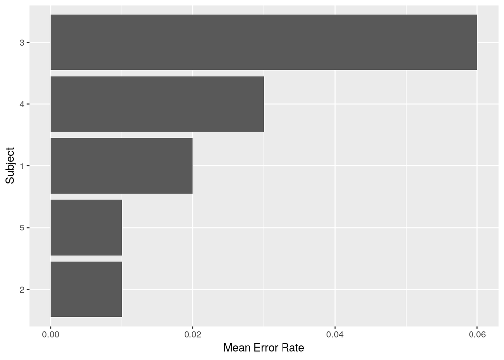

```r
d %>%
  group_by(subject) %>%
  summarize(error = mean(error)) %>%
  ggplot(aes(x = reorder(subject, error) , y = error)) + geom_bar(stat='identity') + coord_flip() +
  xlab('Subject') + ylab('Mean Error Rate')
```

Error rates are very low overall.

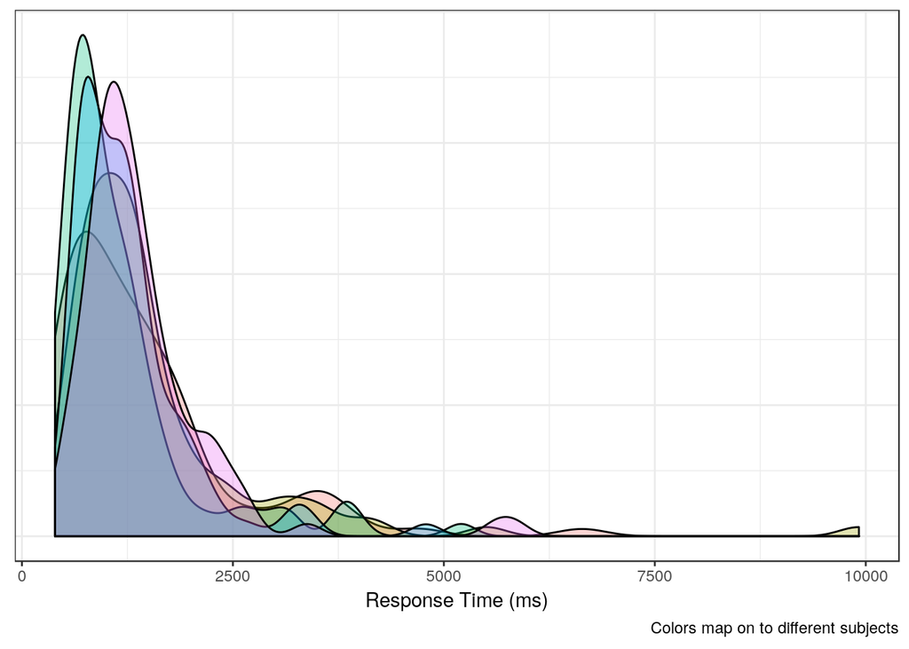

```r
d$subject <- as.factor(d$subject)
d %>%
  ggplot(aes(x = rt, group = subject)) + geom_density(aes(fill = subject), alpha = .3) +
  xlab('Response Time (ms)') +
  theme_bw() +
  labs(caption = 'Colors map on to different subjects') +
  theme(legend.position = 'none',
        axis.title.y = element_blank(),
        axis.ticks.y = element_blank(),
        axis.text.y = element_blank())
```

These distibutions look very acceptable, good job, RAs.

## Switch Cost

The last thing we can really look for in these data is evidence of the switch cost. I’ll break it down by subject since there are only five.

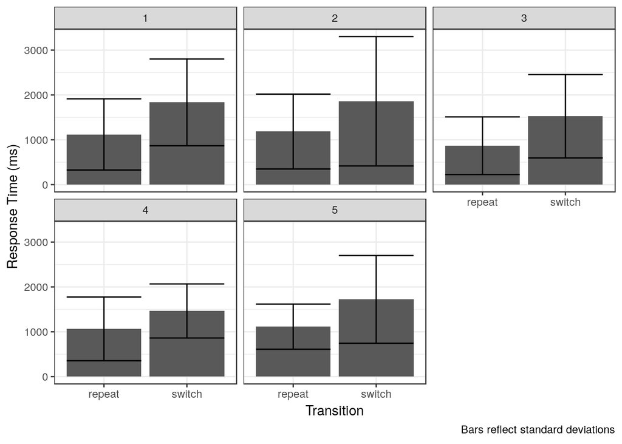

```r
d %>%
  ## coding a correct transition variable
  mutate(transition = ifelse(taskCode == shift(taskCode), 'repeat', 'switch')) %>%
  filter(error == 0, transition != 'startBlock') %>%
  group_by(subject, transition) %>%
  summarize(rTime = mean(rt), sd = sd(rt)) %>%
  ggplot(aes(x = transition, y = rTime)) +
  geom_bar(stat = 'identity') +
  geom_errorbar(aes(ymin = rTime - sd, ymax = rTime + sd)) +
  labs(caption = 'Bars reflect standard deviations') +
  xlab('Transition') +
  ylab('Response Time (ms)') +
  theme_bw() +
  facet_wrap(~subject)
```

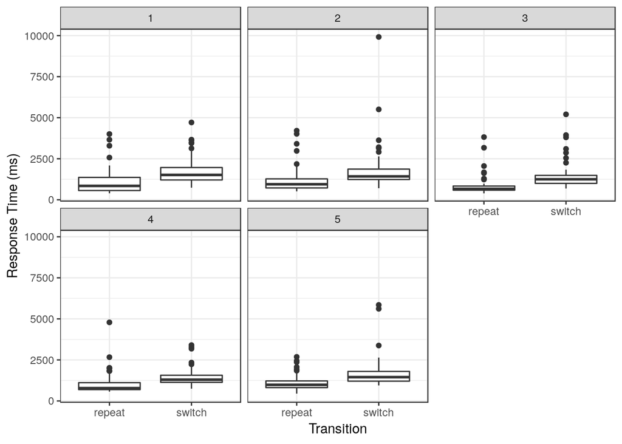

```r
d %>%
  ## coding a correct transition variable
  mutate(transition = ifelse(taskCode == shift(taskCode), 'repeat', 'switch')) %>%
  filter(error == 0, transition != 'startBlock') %>%
  ggplot(aes(x = transition, y = rt)) +
  geom_boxplot() +
  xlab('Transition') +
  ylab('Response Time (ms)') +
  theme_bw() +
  facet_wrap(~subject)
```

Looks like switch costs are coming through. The box plot reveals that the large standard deviations in the bar graph are likely driven by RT outliers (> 5000) that I’m not trimming.

## Final Thoughts

I’m happy with these data overall. Although, I’ll have to go back and see what happened with the coding of that transition variable.